# Agrupando usuários do 8tracks por suas percepções de músicas relaxantes

Daniel Gondim

Neste notebook irei mostrar um experimento que realizei para identificar grupos de usuários da plataforma 8tracks(https://8tracks.com/) que compartilham mesmas percepções sobre músicas relaxantes.

### Preparando os dados

Adicionando .csv criado após recuperar as informações acústicas das músicas das playlists relaxantes dos usuários. Para usuários que possuíam mais de uma música listada, foi utilizada a médias das features dessas músicas para representar o usuário.

```r
data <- read.csv("/home/danielgondim/workspace-new/phd/experiments/qualificacao/users_relax.csv")
head(data)
```

|  | user_id | energy | liveness | tempo | speechiness | acousticness | instrumentalness | danceability | loudness | valence |
| --- | --- | --- | --- | --- | --- | --- | --- | --- | --- | --- |
| 1 | User_303972 | 0.7015000 | 0.2008667 | 127.7072 | 0.06190000 | 0.04316733 | 0.17437325 | 0.4640000 | -8.334000 | 0.3416167 |
| 2 | User_217668 | 0.6094154 | 0.1254154 | 128.2673 | 0.03523846 | 0.33465077 | 0.11574712 | 0.4863077 | -8.371769 | 0.4588462 |
| 3 | User_1274159 | 0.5478750 | 0.1556375 | 119.5205 | 0.15341250 | 0.38626250 | 0.16506850 | 0.6882500 | -8.561375 | 0.5545000 |
| 4 | User_443358 | 0.3998045 | 0.1670500 | 121.8133 | 0.03764091 | 0.60441727 | 0.06183915 | 0.5004091 | -10.774636 | 0.3756364 |
| 5 | User_214048 | 0.5998333 | 0.1388500 | 108.5642 | 0.03835000 | 0.18931455 | 0.14489764 | 0.5511667 | -7.826500 | 0.3733333 |
| 6 | User_131980 | 0.4759167 | 0.1757000 | 103.0800 | 0.05403333 | 0.36308333 | 0.25341333 | 0.5408333 | -9.599667 | 0.3261667 |

Fazendo uma simples manipulação no dataframe para dar nome à cada entrada (linha).

```r
temp <- data[,-1]
rownames(temp) <- data[,1]
data <- temp
head(data)
```

|  | energy | liveness | tempo | speechiness | acousticness | instrumentalness | danceability | loudness | valence |
| --- | --- | --- | --- | --- | --- | --- | --- | --- | --- |
| User_303972 | 0.7015000 | 0.2008667 | 127.7072 | 0.06190000 | 0.04316733 | 0.17437325 | 0.4640000 | -8.334000 | 0.3416167 |
| User_217668 | 0.6094154 | 0.1254154 | 128.2673 | 0.03523846 | 0.33465077 | 0.11574712 | 0.4863077 | -8.371769 | 0.4588462 |
| User_1274159 | 0.5478750 | 0.1556375 | 119.5205 | 0.15341250 | 0.38626250 | 0.16506850 | 0.6882500 | -8.561375 | 0.5545000 |
| User_443358 | 0.3998045 | 0.1670500 | 121.8133 | 0.03764091 | 0.60441727 | 0.06183915 | 0.5004091 | -10.774636 | 0.3756364 |
| User_214048 | 0.5998333 | 0.1388500 | 108.5642 | 0.03835000 | 0.18931455 | 0.14489764 | 0.5511667 | -7.826500 | 0.3733333 |
| User_131980 | 0.4759167 | 0.1757000 | 103.0800 | 0.05403333 | 0.36308333 | 0.25341333 | 0.5408333 | -9.599667 | 0.3261667 |

Para realizar a análise devemos inicialmente normalizar os dados. Uma vez que nosso dataframe é composto apenas de atributos númericos, podemos normalizá-los de forma simples e direta, utilizando a função scale.

```r
data <- scale(data)
summary(data)
```

```
     energy              liveness           tempo           speechiness        acousticness
 Min.   :-2.8348107   Min.   :-1.7729   Min.   :-7.04951   Min.   :-1.32286   Min.   :-1.71215
 1st Qu.:-0.6765993   1st Qu.:-0.6025   1st Qu.:-0.53169   1st Qu.:-0.45303   1st Qu.:-0.77847
 Median : 0.0003631   Median :-0.2205   Median :-0.01494   Median :-0.31444   Median :-0.05111
 Mean   : 0.0000000   Mean   : 0.0000   Mean   : 0.00000   Mean   : 0.00000   Mean   : 0.00000
 3rd Qu.: 0.7189149   3rd Qu.: 0.2926   3rd Qu.: 0.50566   3rd Qu.:-0.01679   3rd Qu.: 0.71370
 Max.   : 2.7519757   Max.   : 9.9829   Max.   : 5.79723   Max.   :12.00364   Max.   : 2.29092
 instrumentalness   danceability         loudness          valence
 Min.   :-0.8017   Min.   :-4.76137   Min.   :-7.8967   Min.   :-2.35730
 1st Qu.:-0.7723   1st Qu.:-0.51257   1st Qu.:-0.4357   1st Qu.:-0.67704
 Median :-0.3787   Median : 0.01168   Median : 0.1314   Median :-0.05821
 Mean   : 0.0000   Mean   : 0.00000   Mean   : 0.0000   Mean   : 0.00000
 3rd Qu.: 0.3560   3rd Qu.: 0.54016   3rd Qu.: 0.6596   3rd Qu.: 0.60479
 Max.   : 3.3735   Max.   : 4.02419   Max.   : 2.6895   Max.   : 3.48041
```

### Determinando um número ótimo de grupos a serem criados

Após normalizarmos os dados, foi possível partir para a atividade de agrupá-los. Para tal, foi escolhido o algoritmo K-means(https://en.wikipedia.org/wiki/K-means_clustering). Para utilizar este algoritmo, devemos previamente informar o valor dos K grupos que desejamos identificar nos nossos dados. Para identificar o valor ideal para o K existem algumas técnicas que podem ser aplicadas, dentre elas: *elbow method*, *silhouette method* e o *gap statistic*.

Para a utilização dos métodos citados anteriormente para identificar um valor ideal de K, devemos carregar dois pacotes, quais sejam: factoextra e NbClust

```r
library(factoextra)
library(NbClust)
```

#### *Elbow Method*

O primeiro método utilizado foi o *elbow method*. No gráfico podemos perceber que o número 4 seria o valor ideal (porém com pouca diferença para o valor 3).

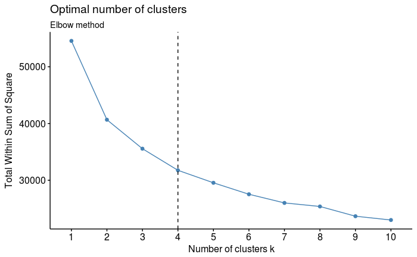

```r
fviz_nbclust(data, kmeans, method = "wss") +
  geom_vline(xintercept = 4, linetype = 2)+
  labs(subtitle = "Elbow method")
```

#### *Silhouette Method*

Por este método o valor ideal para o K seria 2.

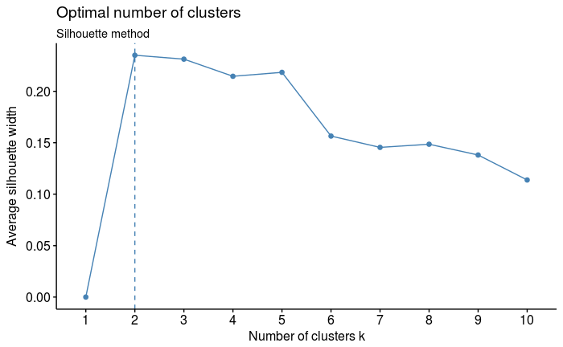

#### *Gap Statistic*

Por fim, utilizando o método *gap statistic*, foi indicado um valor ideal de 4 para o número de grupos a serem gerados.

```
Clustering k = 1,2,..., K.max (= 10): .. done
Bootstrapping, b = 1,2,..., B (= 50)  [one "." per sample]:
.................................................. 50
```

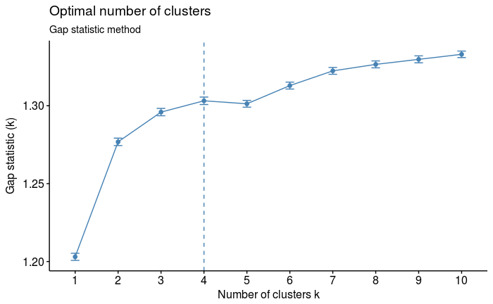

### Aplicando o agrupamento

Após a aplicação de três diferentes métodos para indicar um valor ideal para K, escolhemos o valor 4 já que foi o valor indicado por dois destes métodos.

Como já foi comentado, para o agrupamento iremos utilizar o algoritmo K-means, como podemos observar abaixo.

```r
clusters <- kmeans(data, 4)
str(clusters)
```

```
List of 9
 $ cluster     : Named int [1:6064] 4 4 1 2 4 2 4 3 2 3 ...
  ..- attr(*, "names")= chr [1:6064] "User_303972" "User_217668" "User_1274159" "User_443358" ...
 $ centers     : num [1:4, 1:9] 0.957 -0.595 -1.462 0.783 0.524 ...
  ..- attr(*, "dimnames")=List of 2
  .. ..$ : chr [1:4] "1" "2" "3" "4"
  .. ..$ : chr [1:9] "energy" "liveness" "tempo" "speechiness" ...
 $ totss       : num 54567
 $ withinss    : num [1:4] 3492 10086 4381 13795
 $ tot.withinss: num 31754
 $ betweenss   : num 22813
 $ size        : int [1:4] 351 2628 529 2556
 $ iter        : int 4
 $ ifault      : int 0
 - attr(*, "class")= chr "kmeans"
```

Para o agrupamento K-means, utilizando a distância euclidiana entres os pontos como o fator para agregação, um dado importante que podemos analisar é o centróide de cada grupo gerado. Para isso podemos analisar a seguinte tabela, onde temos os valores dos centros de cada cluster para cada feature analisada.

```r
centroids <- clusters$centers
head(centroids)
```

```
      energy   liveness       tempo speechiness acousticness instrumentalness danceability   loudness
1  0.9570703  0.5240807 -0.28611922  3.25135723   -0.8613607       -0.4359360    1.2686588  0.7251599
2 -0.5951623 -0.1985667 -0.07605721 -0.31557475    0.5935751       -0.1620005   -0.1763888 -0.3198724
3 -1.4618650 -0.2552600 -0.58342365 -0.25774572    1.3336909        1.9781313   -1.5409701 -2.0363018
4  0.7830522  0.1850209  0.23823838 -0.06868093   -0.7680361       -0.1829736    0.3260656  0.6507423
     valence
1  1.0534364
2 -0.3565517
3 -1.3457347
4  0.5004521
```

Para uma melhor análise da tabela acima, podemos gerar um gráfico de coordenadas paralelas. Neste gráfico o Cluter 1 está representado pela cor preta, o Cluster 2 pela cor vermelha, o Cluster 3 pela cor Verde e o Cluster 4 pela cor azul.

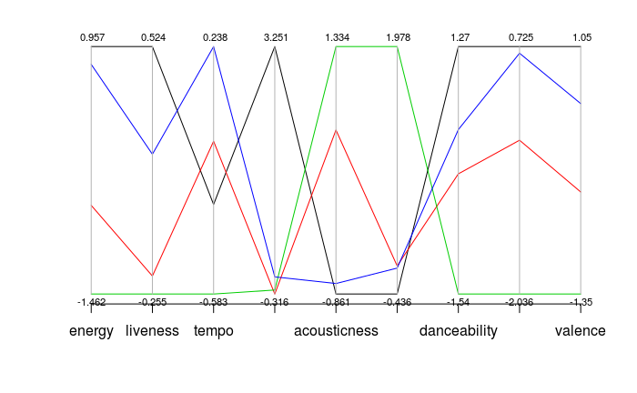

```r
library(MASS)
parcoord(clusters$centers, var.label=TRUE, col = rownames(clusters$centers))
```

- Neste gráfico podemos perceber algumas coisas:
  - As percepções de músicas relaxantes são bem distintas entre os grupos, principalmente entre os clusters 1 e 3.
  - Os clusters 2 e 4 possuem uma variação semelhante de valores das features
  - O cluster 3 define como relaxante basicamente músicas acústicas e instrumentais
  - O cluster 1 define como relaxante músicas mais enérgicas e dançantes (o que pode gerar uma nova análise para identificar quais os gêneros dessas músicas)

Outra análises podem ser feitas posteriormente…